# Systematic reviews and meta-analysis

Adam La Caze

Semester 1, 2023

## Objectives

- Be able to describe the role of systematic reviews and meta-analyses in therapeutic decision-making
- Be able to distinguish between systematic and narrative reviews
- Be able to critically appraise systematic reviews and be able to make a judgement regarding the strengths and limitations of specific systematic reviews and meta-analyses

## Key concepts

- Well-conducted randomized trials often provide the best evidence for judging the efficacy of a treatment
- Systematic reviews take a scientific approach to combining the results of research in a particular area
- Well-conducted systematic reviews can overcome the limitations of randomized trials
- Meta-analyses provide statistical measures of the data combined in systematic review

# Evidence and Decisions

## Levels of evidence

This is a summary of Oxford Center for Evidence-based Medicine’s (2011) levels of evidence for assessing drug benefits. The document provides guidance for grading evidence higher or lower based on methodological considerations and effect sizes.

| Levels | Treatment benefits |
| --- | --- |
| 1 | Systematic review of randomized controlled trials, n-of-1 studies |
| 2 | Randomized controlled trial or observational studies with dramatic effect |
| 3 | Non-randomized controlled cohort of follow-up study with sufficient numbers |
| 4 | Case-series, case-control, or historically controlled studies |
| 5 | Mechanism-based reasoning |

## Bias

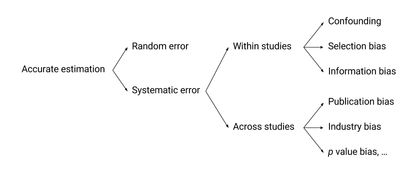

# Systematic Reviews

## What are systematic reviews?

- A systematic review adopts a **scientific** approach to combining and/or contrasting the results of research in a particular area
- The overall structure of a good systematic review is similar to any good clinical study: clear research question, clear and detailed study plan including how the results will be analysed, well-justified inclusion and exclusion criteria, …
- Systematic reviews that use statistical approaches to combine data from the original studies are **meta-analyses**

## Narrative Reviews

- A good narrative review involves an **expert** critically reviewing the literature in on specific topic
- Narrative reviews often make a case for a particular interpretation of the data
- Usually discuss and incorporate different types of evidence (c.f. systematic reviews combine studies with similar methods)
- The “introduction” section of most clinical studies is a type of narrative review

## Key components of meta-analyses

1. Clear research question
2. Replicable literature search strategy (ideally including published and unpublished results)
3. Explicit (and well-justified) inclusion and exclusion criteria
4. Formal assessment of each study for risk of bias
5. Description of individual study results
6. Explanatory analysis of differences between studies and study results
7. Aggregated results (e.g. [forest plot](http://en.wikipedia.org/wiki/Forest_plot)) providing results are suitably **homogeneous**
8. Summary of limitations

It is Step 7 (if it can be done) that makes something a meta-analysis. There are standard statistical tests that help to inform whether it is appropriate to aggregate results into a meta-analysis.

## Why do we need meta-analyses?

Many important effects and harms are modest in size

- Many (most) clinical studies are not large enough to detect small but important effects or harms
  - The random error present in small studies can be enough to mask small-to-modest effect sizes
- Since most trials are powered for treatment benefits, this is a particular problem for treatment **harms** and assessing the effects of a treatment in **subgroups**

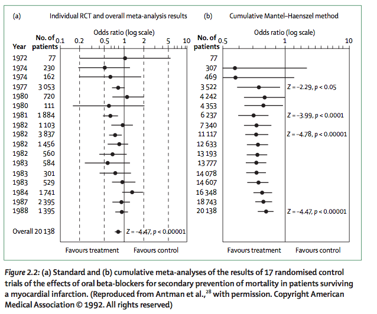

## Limitations and challenges of meta-analyses

Meta-analyses rely on some big assumptions. Judging whether these assumptions are appropriate is difficult.

1. The reviewed studies are of high quality and without systematic bias
2. The studies reviewed are comprehensive (no publication bias)
3. The effect the meta-analysis is estimating is constant across the studies, i.e. the studies are **homogeneous**

## Homogeneity Assumption

- Clinical trials are not repeated; different trials are conducted in different populations and in patients with differing levels of baseline risk.
- Typically we know the homogeneity assumption is false
- The question is whether the degree of heterogeneity is large enough to effect the observed result of the meta-analysis

## Meta-analyses versus Randomized trials

- Well-conducted meta-analyses have the biggest impact when they combine a series of small randomized trials that enrol similar patients, use similar methods and report similar results.
- Things get complicated when meta-analyses provide conflicting results, when multiple randomized trials provide conflicting results, or when meta-analyses and randomized trials provide conflicting results

Due to the limitations of meta-analysis, a single well-conducted *large* randomized trial will likely provide better evidence than a meta-analysis of many small trials

# Examples and discussion

## Atypical antipsychotics in dementia

- Atypical antipsychotics (quetiapine, olanzapine, etc) are frequently used for changed behaviour in patients with dementia
- Most trials assessing the use of antipsychotics in dementia patients are small and powered to demonstrate benefits (c.f. harms). Trials typically involve 200–600 patients and go for up to 12 weeks.

Schneider et al. (2005) conduct a meta-analysis of these trials. The overall odds ratio (95% CI) for death for patients receiving atypical antipsychotics compared to placebo is 1.54 (1.06–2.23)

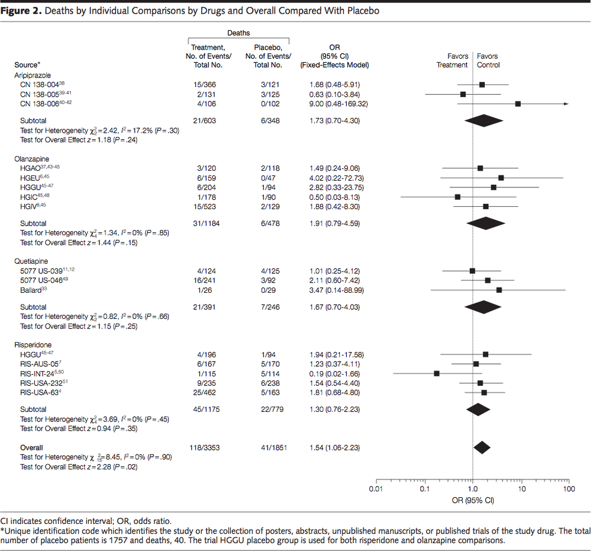

## Publication bias and reboxetine

## Reboxetine (Eyding et al., 2010)

- Reboxetine is an antidepressant marketed in several countries (and remains available in Australia)
- Eyding et al. (2010) reports a meta-analysis of trials in major depression that compared reboxetine to placebo or SSRI
- Data on 74% of all the participants involved in reboxetine trials were unpublished

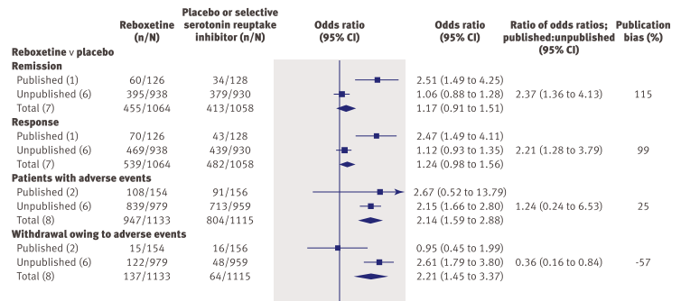

## Rosiglitazone and cardiovascular risks

- There appears to be a relatively clear signal that rosiglitazone increases the risk of cardiovascular events (Rosen, 2010), but there is still uncertainty
- Nissen & Wolski (2007) is an early meta-analysis showing an association between rosiglitazone and cadiovascular events; odds ratio for myocardial infarction 1.43 (95% CI: 1.03–1.98, $p = 0.03$)
- Home et al. (2007) is a large open-labelled randomized trial stopped early following the publication of the meta-analysis. The primary endpoint for the trial was hospitalization or death from cardiovascular causes, the observed hazard ratio: 1.11 (95% CI: 0.93–1.32)

## References

Eyding, D., Lelgemann, M., Grouven, U., Harter, M., Kromp, M., Kaiser, T., MF, K., Gerken, M., & Wieseler, B. (2010). Reboxetine for acute treatment of major depression: Systematic review and meta-analysis of published and unpublished placebo and selective serotonin reuptake inhibitor controlled trials. *BMJ (Online)*, *341*(7777), 816. https://doi.org/http://dx.doi.org/10.1136/bmj.c4737

Home, P. D., Pocock, S. J., Beck-Nielsen, H., Gomis, R., Hanefeld, M., Jones, N. P., Komajda, M., McMurray, J. J. V., & the, R. S. G. (2007). Rosiglitazone Evaluated for Cardiovascular Outcomes -- An Interim Analysis. *N Engl J Med %R 10.1056/NEJMoa073394*, *357*(1), 28–38.

Nissen, S. E., & Wolski, K. (2007). Effect of Rosiglitazone on the Risk of Myocardial Infarction and Death from Cardiovascular Causes. *New England Journal of Medicine*, *356*(24), 2457–2471. https://doi.org/10.1056/NEJMoa072761

Rosen, C. J. (2010). Revisiting the Rosiglitazone Story---Lessons Learned. *New England Journal of Medicine*. http://content.nejm.org/

Rothman, K. J., Greenland, S., & Lash, T. L. (2008). Validity in epidemiologic studies. In K. J. Rothman, S. Greenland, & T. L. Lash (Eds.), *Modern Epidemiology* (3rd ed., pp. 128–147). Lippincott Williams & Wilkins. https://doi.org/10.1016/B978-0-443-06954-3.00009-8

Schneider, L. S., Dagerman, K. S., & Insel, P. (2005). Risk of death with atypical antipsychotic drug treatment for dementia: meta-analysis of randomized placebo-controlled trials. *JAMA: The Journal of the American Medical Association*, *294*(15), 1934–1943. https://doi.org/10.1001/jama.294.15.1934